# 2. Regression analysis

In this chapter I will:

- Introduce the data set
- Describe the use of regression analysis as a method.
- Describe the results obtained from regression analysis.
- Summarize what I learned in this exercise.

The preceding data wrangling exercise is available [here.](https://github.com/palsola/IODS-project/blob/master/data/create_learning2014.R)

*I will assume that the reader has an introductory course level understanding of writing and reading R code as well as statistical methods, and that he/she has no previous knowledge of your data or the more advanced methods you are using.*

```
## [1] "Fri Nov 06 09:42:18 2020"
```

Here we go again…

## Description of data

```r
learning2014 <- read.table("C:/Users/minttu/R projects/IODS-project/data/Learning 2014.txt", header = T)

# explore the structure and the dimensions of the data
dim(learning2014)
```

```
## [1] 166   7
```

```r
str(learning2014)
```

```
## 'data.frame':    166 obs. of  7 variables:
##  $ gender  : Factor w/ 2 levels "F","M": 1 2 1 2 2 1 2 1 2 1 ...
##  $ age     : int  53 55 49 53 49 38 50 37 37 42 ...
##  $ attitude: num  3.7 3.1 2.5 3.5 3.7 3.8 3.5 2.9 3.8 2.1 ...
##  $ deep    : num  3.58 2.92 3.5 3.5 3.67 ...
##  $ stra    : num  3.38 2.75 3.62 3.12 3.62 ...
##  $ surf    : num  2.58 3.17 2.25 2.25 2.83 ...
##  $ points  : int  25 12 24 10 22 21 21 31 24 26 ...
```

The dataset used here is an extract from a wider dataset (N=183) collected on the *Introduction to Social Statistics* course during 3.12.2014 - 10.1.2015 by Kimmo Vehkalahti. The international survey of Approaches to Learning was used for data collection. The current dataset used for this excercise has 166 observations of 7 variables: gender (M/F), age (in years), global attitude towards statistics (mean sumscore of 10 items), 3 learning type mean sumscore variables (deep; 12 items, strategic; 8 items, and surface; 12 items), and exam score (points).

A more detailed summary of the dataset below:

```r
summary(learning2014)
```

```
##  gender       age           attitude          deep            stra
##  F:110   Min.   :17.00   Min.   :1.400   Min.   :1.583   Min.   :1.250
##  M: 56   1st Qu.:21.00   1st Qu.:2.600   1st Qu.:3.333   1st Qu.:2.625
##          Median :22.00   Median :3.200   Median :3.667   Median :3.188
##          Mean   :25.51   Mean   :3.143   Mean   :3.680   Mean   :3.121
##          3rd Qu.:27.00   3rd Qu.:3.700   3rd Qu.:4.083   3rd Qu.:3.625
##          Max.   :55.00   Max.   :5.000   Max.   :4.917   Max.   :5.000
##       surf           points
##  Min.   :1.583   Min.   : 7.00
##  1st Qu.:2.417   1st Qu.:19.00
##  Median :2.833   Median :23.00
##  Mean   :2.787   Mean   :22.72
##  3rd Qu.:3.167   3rd Qu.:27.75
##  Max.   :4.333   Max.   :33.00
```

### Graphic overview

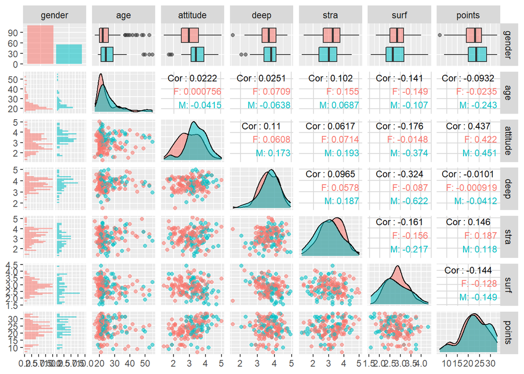

```r
# access libraries
library(ggplot2)
library(GGally)

# graphic overview

graphic_overview <- ggpairs(learning2014,
             mapping = aes(col = gender, alpha = 0.3),
             upper = list(continuous = wrap("cor", size = 3, alignPercent = 1)),
             lower = list(combo = wrap("facethist", bins = 30)))

graphic_overview
```

Scatter plots seem quite evenly spread - except for plots paired with age as most respondents are at the younger end.

**Side note**: If someone knows how to spread out the figure a little more in order to better see the values at the bottom, let me know!

## Regression model

To investigate what (combination of) the variables in the data could explain the level of success in the course exam, I am conducting a multivariate linear regression analysis. Regression analysis allow assessments of the relationship multiple independent variable sand a dependent variable. In multivariate regression models it is possible to have more than one independent variable which allows, e.g., controlling for possible confounding factors. The optimal set of independent variables is the smallest reliable uncorrelated set that explains enough of the variance in the dependent variable.

Hence, the final model is as follows:

```r
# regression model and summary
my_model <- lm(points ~ attitude, data = learning2014)
summary(my_model)
```

```
##
## Call:
## lm(formula = points ~ attitude, data = learning2014)
##
## Residuals:
##      Min       1Q   Median       3Q      Max
## -16.9763  -3.2119   0.4339   4.1534  10.6645
##
## Coefficients:
##             Estimate Std. Error t value Pr(>|t|)
## (Intercept)  11.6372     1.8303   6.358 1.95e-09 ***
## attitude      3.5255     0.5674   6.214 4.12e-09 ***
## ---
## Signif. codes:  0 '***' 0.001 '**' 0.01 '*' 0.05 '.' 0.1 ' ' 1
##
## Residual standard error: 5.32 on 164 degrees of freedom
## Multiple R-squared:  0.1906, Adjusted R-squared:  0.1856
## F-statistic: 38.61 on 1 and 164 DF,  p-value: 4.119e-09
```

```r
confint(my_model, level = 0.95)
```

```
##                2.5 %    97.5 %
## (Intercept) 8.023074 15.251233
## attitude    2.405135  4.645785
```

For a given predictor variable, the coefficient (Estimate) can be interpreted as the average effect on exam scores of a one unit increase in predictor, holding all other predictors fixed. So, a 1-point increase in attitude (on a scale from 1-5) will, on average, increase points achieved in the exam by 3.53.

## Diagnosic plots

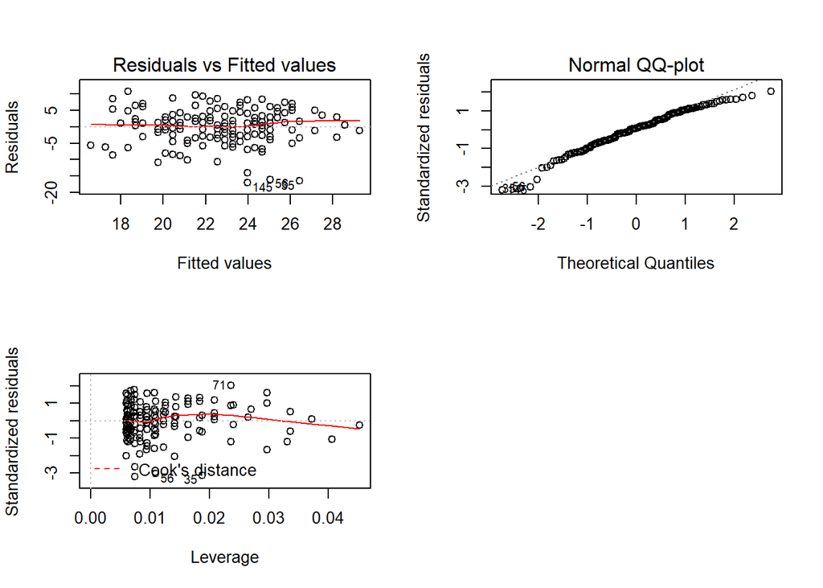

```r
# diagnostic plots
par(mfrow = c(2,2))
plot(my_model, which = c(1,2,5),
     caption = list("Residuals vs Fitted values", "Normal QQ-plot", "Residuals vs. Leverage"))
```

Multivariate regression assumes independence of the residuals, that is, normality, linearity, and homoscedasticity.

It is assumed that:

1. The errors are normally distributed
2. The errors are not correlated
3. The errors have constant variance
4. The size of a given error does not depend on the size of explanatory variables

The assumption of constant variance can be explored from the scatter plot where any pattern implies a violation of the assumption. Here, the pattern seems otherwise relatively random, but some clustering can be detected at the lower right-hand corner of the chart.

QQ- plot of the residuals provides a method to explore the assumption that the errors of the model are normally distributed. Here, the points fall nicely on the line in the middle, but some deviations can be detected at both ends, indicating a possible violation of this assumption.

For this model to better predict the exam scores, the more influential values and outliers should either be deleted or given a score that is not too far from the rest.

## Learning points

In this exercise I learned how to visualize data, conduct a simple regression analysis and create diagnostic plots. I have conducted regression analysis using SPSS before, so the method itself was not new. However, SPSS has only limited selection of diagnostic tools, and I had never seen nor analyzed a Leverage vs. Residuals scatter plot - so that was completely new to me!

In terms of using R, everything is always new! So this week I learned many useful commands to get started with basic analyses and built a good foundation to move on to more refined analyses.